# Homework 3

Elif Konyar - IE582 - Fall 2018

## TASK 1

In this task, we are given a collection of datasets from the library, uWaveGestureLibrary, which consists over 4000 gesture instances with the accelerometer readings in three dimensions seperately. There are 896 instances in the training set and 3582 instances in the test set.

```r
x_train<-fread("/Users/elifkonyar/Desktop/IE 582/HW3/UWave_TRAIN/uWaveGestureLibrary_X_TRAIN")
y_train<-fread("/Users/elifkonyar/Desktop/IE 582/HW3/UWave_TRAIN/uWaveGestureLibrary_Y_TRAIN")
z_train<-fread("/Users/elifkonyar/Desktop/IE 582/HW3/UWave_TRAIN/uWaveGestureLibrary_Z_TRAIN")
x_test<-fread("/Users/elifkonyar/Desktop/IE 582/HW3/UWave_TEST/uWaveGestureLibrary_X_TEST")
y_test<-fread("/Users/elifkonyar/Desktop/IE 582/HW3/UWave_TEST/uWaveGestureLibrary_Y_TEST")
z_test<-fread("/Users/elifkonyar/Desktop/IE 582/HW3/UWave_TEST/uWaveGestureLibrary_Z_TEST")
```

### PART A

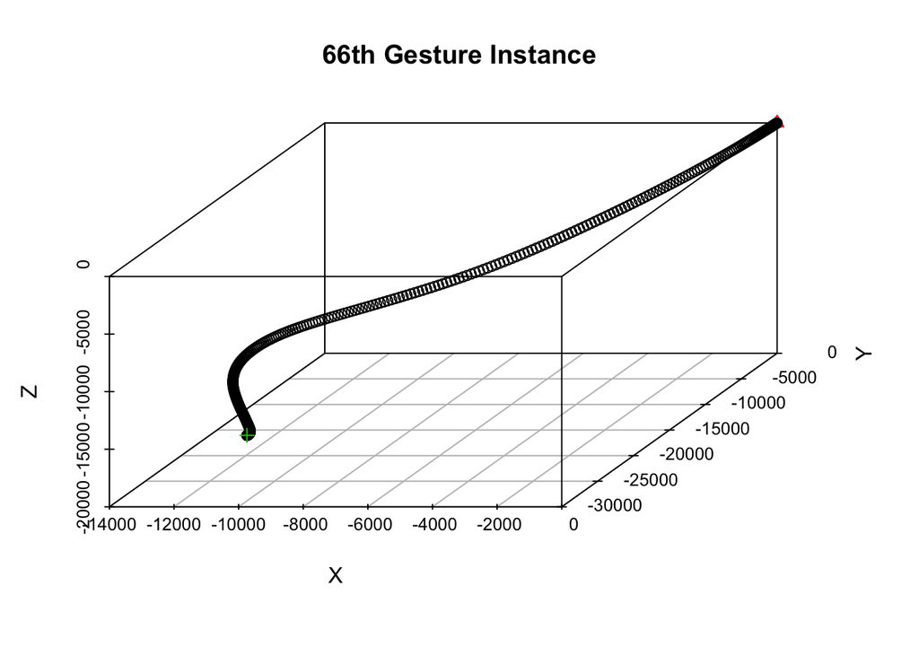

The example of the type 2 gesture:

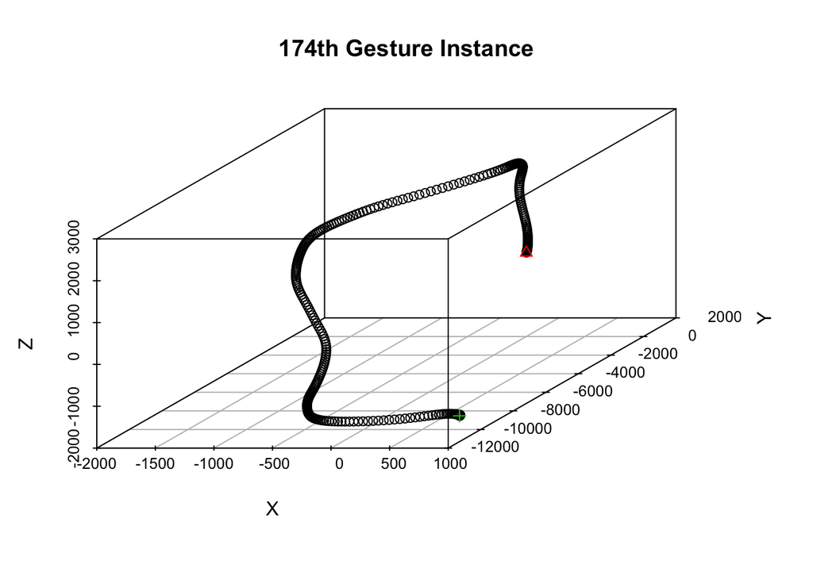

The example of the type 3 gesture:

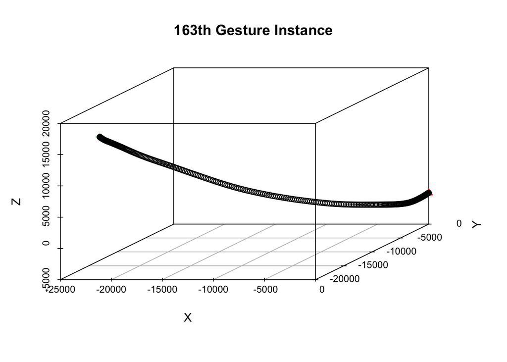

The example of the type 4 gesture:

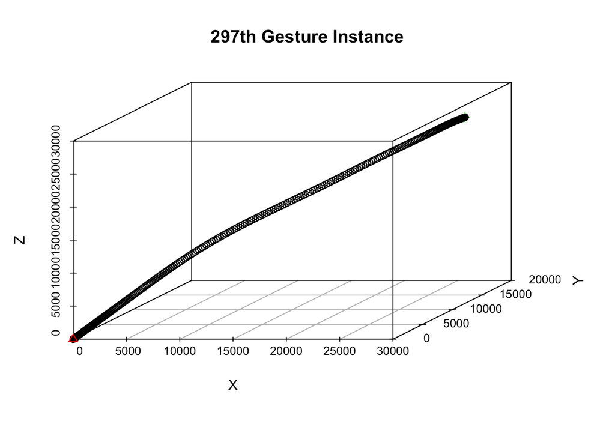

The example of the type 5 gesture:

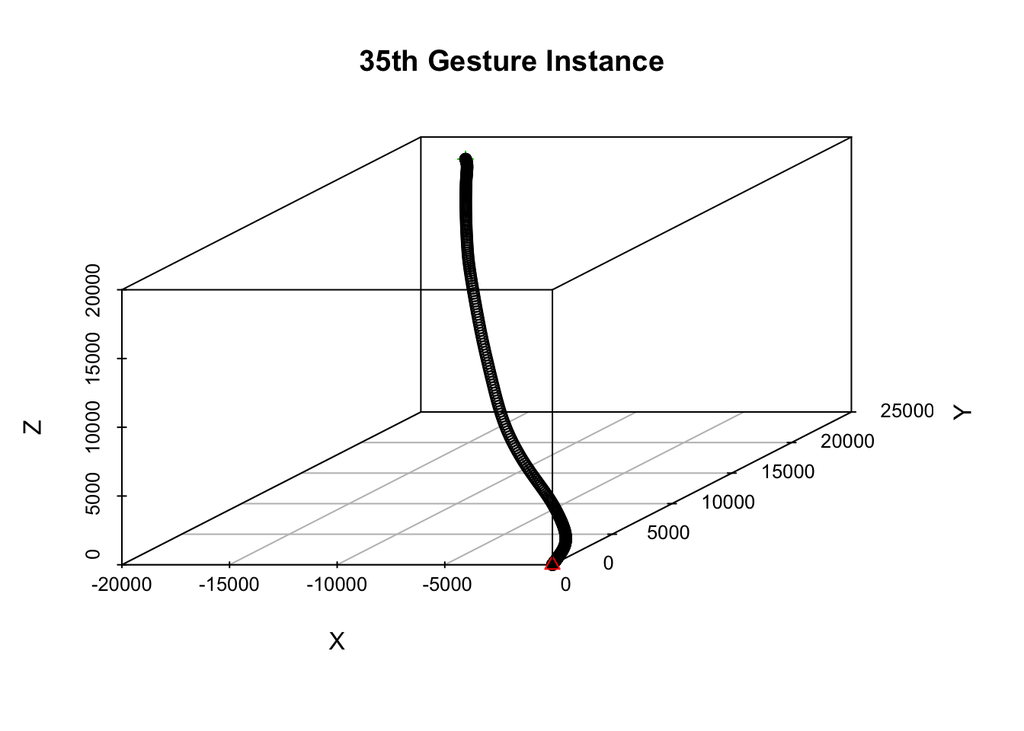

The example of the type 6 gesture:

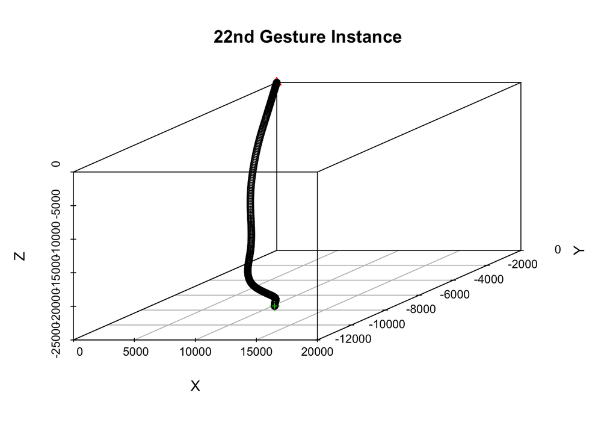

The example of the type 7 gesture:

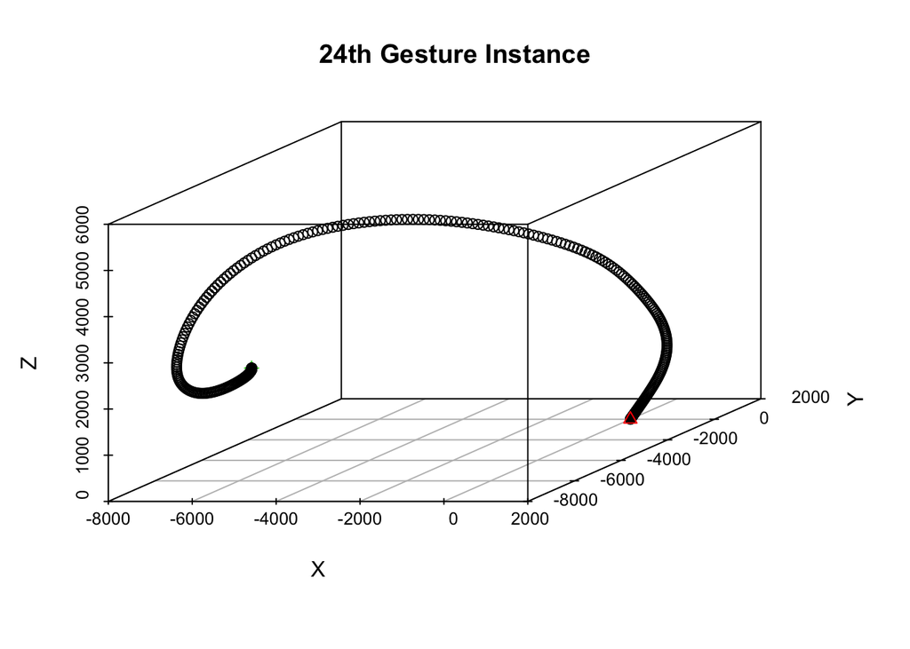

The example of the type 8 gesture:

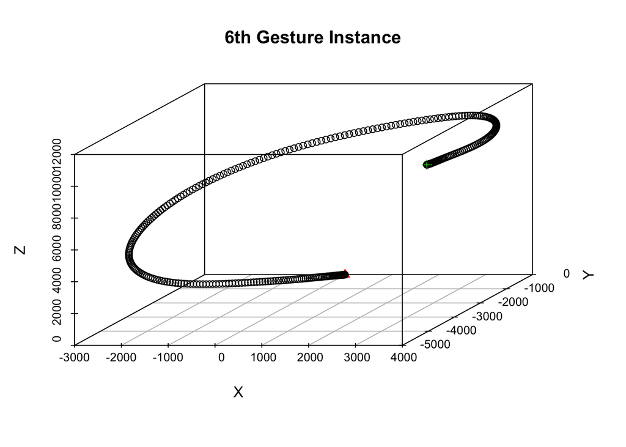

### PART B

In this part, we are asked to perform 10-fold cross-validation in training data in order to find the k parameter that will be used in nearest-neighbour (NN) classifier to find the labels of the test instances. As the first step, the three datasets corresponding to x, y and z directions are combined such that each instance has the accelaration information along these directions in order in a row.

As the distance measure, Euclidean and Manhattan distance will be calculated. The k levels that will be tried are 1, 3, 5 and 7. The indices for each fold are generated at the beginning; so that, the same folds can be used in different trials of k and distance measure.

#### Euclidean Case

For the euclidean distance case, knn() function is used. Its default distance measure is Euclidean distance. For each k value, the same folds are used and the accuracy results for each k value are stored in “cvresult” table.

```
##    Method Klev      Accu
## 1:    knn    1 0.9419643
## 2:    knn    3 0.9441964
## 3:    knn    5 0.9408482
## 4:    knn    7 0.9363839
```

It can be seen that the highest accuracy is achieved when the k value is 3. It minimizes the error, so 3 is chosen as the optimal value.

#### Manhattan Case

For the Manhattan case, the same procedure is applied. However, kknn() function is used for k-NN classifier. The kknn() function uses Minkowski distance as the distance measure. The “p” parameter in Minkowski distance is changed in the “distance” parameter in the kknn() function. When p is 1, it refers to Manhattan distance; so, the “distance” parameter is set to 1. Additionally, this function uses kernel functions to weight the neighbors according to their distances. In order to use no weights in other words in order to apply standard unweighted knn, kernel parameter is set to “rectangular”. In the end, the results for different k values are stored in “cvresult_manhattan” table.

```
##    Method Klev      Accu
## 1:    knn    1 0.9542411
## 2:    knn    3 0.9553571
## 3:    knn    5 0.9497768
## 4:    knn    7 0.9486607
```

It can be seen from the table above that the highest accuracy is achieved when the k value is 3. It minimizes the error, so 3 is chosen as the optimal value.

In conclusion, from the training set results, k is chosen to be 3 for both Euclidean and Manhattan distance case.

### PART C

After determining the k value for each distance measure, the final performances of the models on the test data are evaluated.

#### Euclidean Case

```
## [1] "1.90058 seconds passed during k-NN classification for the Euclidean case!"
```

In the confusion matrix, the actual classes are in the rows, whereas the predicted classes are in the columns. There are 8 classes in total resulting in a 8x8 confusion matrix. In the diagonal, the true predicted instance counts can be seen. The remaining instances are predicted incorrectly.

```
##    predict_knn_euc
##       1   2   3   4   5   6   7   8
##   1 430   0   0   3   0   4   0   0
##   2   1 449   0   0   0   0   2   0
##   3   2   0 414   0  13  21   4   0
##   4   6   0   0 372  59   7   0   6
##   5   3   0   7   1 420   2   0   0
##   6   8   0   5  17  27 391   1   0
##   7   1   0   2   0   0   0 444   0
##   8   0   0   0   1   1   0   0 458
```

The accuracy of the final model is calculated below:

```
## [1] 0.9430486
```

The accuracy of the final model for the Euclidean distance case with k=3 is 0.9430486.

#### Manhattan Case

For the Manhattan case, a similar procedure is applied:

```
## [1] "1.18293 minutes passed during k-NN classification for the Manhattan case!"
```

The similar 8x8 confusion matrix is given below:

```
##
##       1   2   3   4   5   6   7   8
##   1 432   0   0   2   0   3   0   0
##   2   1 451   0   0   0   0   0   0
##   3   2   0 415   0  12  20   5   0
##   4   3   0   0 384  48   8   0   7
##   5   3   0   4   2 422   2   0   0
##   6   6   0   4  12  27 400   0   0
##   7   1   0   2   0   0   0 444   0
##   8   0   0   0   1   1   0   0 458
```

The accuracy of the final model is calculated below:

```
## [1] 0.9508654
```

The accuracy of the final model for the Manhattan distance case with k=3 is 0.9508654.

## TASK 2

In this task, we are asked to use ECG time series data used in the class in order to perform logistic regression with fused penalties. Fused lasso penalties tend to make the coefficients of the close variables close to each other. Thus, it penalizes the difference between the coefficients of the observations at time t and t+1. In order to perform logistic regression with fused penalties “penalized” package is utilized. In penalized package, there are different alternative functions to apply logistic regression with cross-validation. In order to get the optimal lambda value as the output, optL1() function is used for this task.

```r
traindata <- as.data.table(read.table('/Users/elifkonyar/Desktop/IE 582/Codes/NN_Classification/ecgTRAIN'))
testdata <- as.data.table(read.table('/Users/elifkonyar/Desktop/IE 582/Codes/NN_Classification/ecgTEST'))
```

### PART A

In this part, we are asked to train a logistic regression model on the training data using fused lasso penalties. In the code below, the class information is stored in a seperate table where -1’s are updated to 0 for the model building part.

As the next step, logistic regression model is built where fusedl parameter refers to whether it contains the fused penalties or not. Thus, it is set to TRUE. Here, 10-fold cross-validation is applied in the training data in order to obtain the coefficients and the lambda1 value for the model. Lambda2 in this model is 0 by default since we do not apply ridge regression. Epsilon parameter determines the convergence of the objective function. The standardization is done by setting the standardize parameter to TRUE in order to treat all features we have equally. Trace parameter is set to TRUE in order to see the updates in the lambda1 values.

```
## lambda= 8.384078     12345678910cvl= -48.32271
## lambda= 13.56572     12345678910cvl= -56.09914
## lambda= 5.181645     12345678910cvl= -42.91148
## lambda= 3.202433     12345678910cvl= -39.36748
## lambda= 1.979212     12345678910cvl= -38.12636
## lambda= 0.4971482    12345678910cvl= -43.77194
## lambda= 1.413114     12345678910cvl= -38.98263
## lambda= 2.231631     12345678910cvl= -38.23468
## lambda= 2.014971     12345678910cvl= -38.14031
## lambda= 1.762982     12345678910cvl= -38.20904
## lambda= 1.933472     12345678910cvl= -38.09464
## lambda= 1.868351     12345678910cvl= -38.10024
## lambda= 1.907026     12345678910cvl= -38.08186
## lambda= 1.903831     12345678910cvl= -38.08057
## lambda= 1.890279     12345678910cvl= -38.08183
## lambda= 1.898621     12345678910cvl= -38.07853
## lambda= 1.897859     12345678910cvl= -38.07825
## lambda= 1.894964     12345678910cvl= -38.07944
## lambda= 1.897363     12345678910cvl= -38.07824
## lambda= 1.896411     12345678910cvl= -38.07872
## lambda= 1.897135     12345678910cvl= -38.07836
## lambda= 1.897497     12345678910cvl= -38.07818
```

The model output can be seen below:

```
## $lambda
## [1] 1.897497
##
## $cvl
## [1] -38.07818
##
## $predictions
##   [1] 0.17684348 0.96045925 0.30840158 0.56302392 0.96530431 0.94668205
##   [7] 0.13820647 0.77142881 0.95818787 0.75556687 0.68172817 0.56418997
##  [13] 0.09519552 0.98556322 0.23958642 0.86032922 0.98218919 0.99026247
##  [19] 0.34348597 0.17185714 0.79477669 0.86001663 0.93496513 0.16998743
##  [25] 0.94349256 0.23928680 0.88768309 0.02715506 0.94493363 0.98980762
##  [31] 0.98129218 0.98598001 0.84712155 0.95065591 0.96810091 0.19074926
##  [37] 0.84496911 0.96098960 0.25344637 0.98141554 0.53797412 0.59441445
##  [43] 0.95957720 0.13974428 0.52064875 0.97880312 0.80028509 0.31954198
```

[output cut: 30 more lines]

```
##
##      0  1
##   0 25 11
##   1  8 56
```

In this problem, I treat 0’s as positive class since they are less in number. The number of true positives is 25, whereas the number of true negatives is 56. The number of false positives is 8 and of false negatives is 11. By changing the threshold used above, false positive rate and false negative rate can be changed according to the importance of the class.

### PART B

```
##  [1] -0.3193852  0.0000000  0.0000000  0.0000000  0.0000000 -0.1686486
##  [7] -0.3847855  0.0000000  0.0000000  0.0000000  0.0000000  1.1058585
## [13]  0.0000000  0.0000000  0.0000000  0.0000000  0.0000000  0.0000000
## [19]  0.0000000  0.0000000  0.0000000  0.0000000  0.0000000  0.0000000
## [25]  0.0000000  0.0000000  0.0000000  0.0000000  0.0000000 -0.4824095
## [31]  0.0000000  0.0000000  0.0000000 -0.4427628  0.0000000  0.0000000
## [37]  0.0000000  0.0000000  0.0000000  0.0000000  0.0000000  0.0000000
## [43]  0.0000000  0.2771996  0.6085784  0.0000000  0.0000000  0.0000000
## [49]  0.0000000  0.0000000  0.0000000  0.0000000  0.0000000  0.0000000
## [55]  0.0000000  0.0000000  0.0000000  0.0000000  0.0000000  0.0000000
## [61]  0.0000000  0.0000000  0.0000000  0.0000000  0.0000000  0.0000000
## [67]  0.0000000  0.0000000  0.0000000  0.0000000  0.0000000  0.0000000
## [73]  0.0000000  0.0000000  0.0000000  0.0000000  0.0000000  0.0000000
## [79]  0.0000000  0.0000000 -0.4103494  0.0000000  0.0000000  0.0000000
## [85]  0.0000000  0.0000000  0.0000000  0.0000000  0.0000000  0.0000000
## [91]  0.0000000  0.0000000  0.0000000  0.0000000 -1.0408518  0.0000000
```

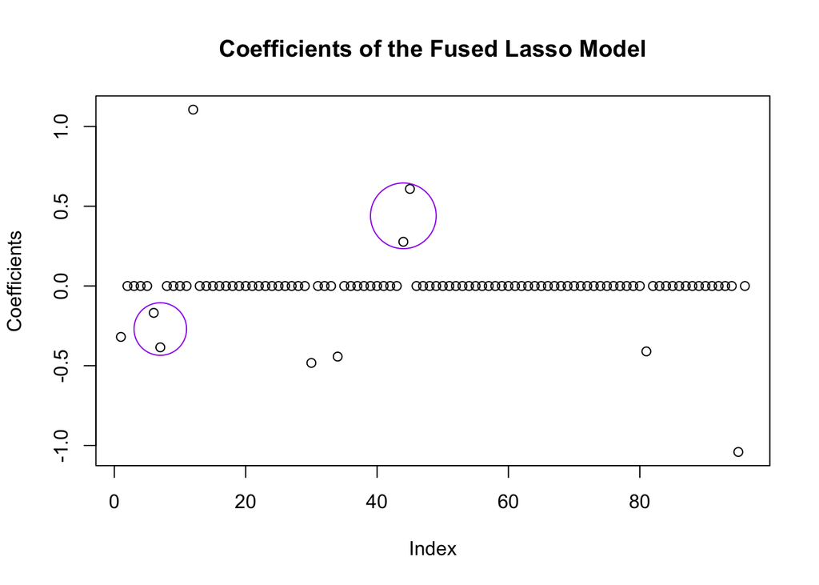

The regression coefficients are seen above. The ones that are estimated as positive refer to the observations that positively affect the probability result. On the other hand, coefficients that are estimated as negative affect the probability prediction negatively. The observations with zero coefficients do not play a significant role in explaining the probability prediction. As from the motive of the fused lasso, the coefficients of the 6th and 7th observation in the first circle, which are both nonzero, can be considered to be close. They are both negative. Similarly, the coefficients of the 44th and 45th observation can be considered to be close.

### PART C

The model is built with similar parameters.

```
## lambda= 5.560364     12345678910cvl= -53.15076
## lambda= 8.996859     12345678910cvl= -57.29428
## lambda= 3.436494     12345678910cvl= -51.01983
## lambda= 2.12387  12345678910cvl= -47.76103
## lambda= 1.312624     12345678910cvl= -46.3388
## lambda= 0.8112462    12345678910cvl= -49.09018
## lambda= 1.559341     12345678910cvl= -46.9874
## lambda= 1.121115     12345678910cvl= -46.14996
## lambda= 1.08536  12345678910cvl= -46.33336
## lambda= 1.198547     12345678910cvl= -45.98465
## lambda= 1.200184     12345678910cvl= -45.98593
## lambda= 1.188802     12345678910cvl= -45.98296
## lambda= 1.162948     12345678910cvl= -46.01834
## lambda= 1.192035     12345678910cvl= -45.98037
## lambda= 1.193092     12345678910cvl= -45.98087
## lambda= 1.191766     12345678910cvl= -45.98058
## lambda= 1.192311     12345678910cvl= -45.98038
```

The model output can be seen below:

```
## $lambda
## [1] 1.192035
##
## $cvl
## [1] -45.98037
##
## $predictions
##   [1] 0.3020215 0.9051813 0.3304091 0.7357802 0.9707879 0.9403376 0.4442205
##   [8] 0.6894033 0.9340826 0.5988829 0.5077050 0.1458293 0.7935440 0.9793662
##  [15] 0.3185744 0.6629534 0.9429968 0.9706768 0.5305128 0.4678650 0.3565412
##  [22] 0.8447894 0.9680521 0.3049989 0.9641830 0.4351628 0.7653472 0.5748648
##  [29] 0.3689960 0.9443722 0.9740397 0.9466325 0.8930385 0.9804785 0.9785360
##  [36] 0.4486855 0.6773038 0.9215214 0.4192951 0.9900965 0.4441957 0.4763827
##  [43] 0.8211151 0.3938621 0.6178389 0.9874656 0.8951780 0.3199527 0.9429680
##  [50] 0.3279247 0.7615296 0.7689834 0.5496848 0.4227561 0.9743362 0.9633398
##  [57] 0.6687256 0.1033457 0.9237418 0.9008529 0.9763569 0.7278026 0.3107440
##  [64] 0.9844595 0.9732757 0.7946264 0.8821498 0.8542626 0.8812994 0.9237580
##  [71] 0.3700286 0.9690995 0.8608125 0.9340899 0.9064869 0.8200376 0.9818095
##  [78] 0.9886395 0.9729928 0.5099305 0.6442108 0.1898354 0.8782732 0.2928430
##  [85] 0.2453843 0.4568481 0.3975490 0.9736126 0.7594597 0.8294880 0.1798827
##  [92] 0.8362930 0.8037451 0.5243583 0.8978554 0.1170798 0.3662146 0.7764869
##  [99] 0.9756714 0.9426589
##
## $fold
##   X1   X2   X3   X4   X5   X6   X7   X8   X9  X10  X11  X12  X13  X14  X15
##    4    2    5    1    6   10    4    4    4    2   10   10    9   10    7
##  X16  X17  X18  X19  X20  X21  X22  X23  X24  X25  X26  X27  X28  X29  X30
##   10    7    2    3    3    9    2    3    5    1    8    8    8    7    7
##  X31  X32  X33  X34  X35  X36  X37  X38  X39  X40  X41  X42  X43  X44  X45
##    6    6    5    2    2    8    9    4    3    5    1    8   10    2    6
##  X46  X47  X48  X49  X50  X51  X52  X53  X54  X55  X56  X57  X58  X59  X60
##   10    6    7    5    3    1    3    7    1   10    4    7    6    1    4
##  X61  X62  X63  X64  X65  X66  X67  X68  X69  X70  X71  X72  X73  X74  X75
##    8    6    3    6    1    2    6    8    1    9    6    4    2    9    7
##  X76  X77  X78  X79  X80  X81  X82  X83  X84  X85  X86  X87  X88  X89  X90
##    9    9    8   10    8    3    5    1    7    4    5    9    2    4    8
##  X91  X92  X93  X94  X95  X96  X97  X98  X99 X100
##    3    9    9    5    7   10    5    5    1    3
##
## $fullfit
## Penalized logistic regression object
## 96 regression coefficients of which 19 are non-zero
##
## Loglikelihood =   -28.21561
## L1 penalty =  12.31679   at lambda1 =  1.192035
```

The lambda1 value that minimizes the loss function is 1.192035. 19 out of 96 regression coefficients are nonzero. As the final step, the model is used to predict the classes for the test data. Similar approach is applied to label the test observations.

```
##
##      0  1
##   0 25 11
##   1 12 52
```

The 0 class are predicted the same as the original data above where 25 of them are predicted correctly and 11 of them incorrectly. On the other hand, the number of truly predicted 1 class observations decreased by 4 in this version. However, these rates can be changed by changing the threshold from 0.5 to another value.

### PART D

```
##  [1]  0.087759092  1.208208422  0.000000000 -0.590289205 -0.006577459
##  [6]  0.000000000  0.229173894  0.226348626  0.542361121  0.064979851
## [11]  0.151527113 -0.056026865  0.000000000  0.000000000  0.000000000
## [16]  0.000000000  0.000000000  0.000000000  0.000000000  0.000000000
## [21]  0.000000000  0.000000000  0.000000000  0.000000000  0.000000000
## [26]  0.000000000  0.000000000 -0.705257742 -0.072782726  0.000000000
## [31]  0.000000000  0.000000000  0.000000000  0.000000000  0.460487475
## [36]  0.000000000  1.834142139  0.000000000  1.142097805  0.000000000
## [41]  0.000000000  0.000000000  0.000000000  0.000000000  0.000000000
## [46]  0.000000000  0.000000000  0.000000000  0.000000000  0.000000000
## [51]  0.000000000  0.000000000  0.000000000  0.000000000  0.000000000
## [56]  0.000000000  0.000000000  0.000000000  0.000000000  0.000000000
## [61]  0.000000000  0.000000000  0.000000000  0.000000000  0.000000000
## [66]  0.000000000  0.000000000  0.000000000  0.000000000  0.000000000
## [71]  0.000000000  0.000000000  0.000000000  0.000000000  0.000000000
## [76]  0.000000000 -1.618670783  0.000000000  0.000000000  0.000000000
## [81]  0.000000000  0.000000000  0.000000000  0.000000000  0.000000000
## [86]  0.000000000  0.000000000  0.000000000  0.000000000  0.000000000
## [91]  0.000000000  0.000000000 -0.785062998 -0.550825552  0.000000000
```

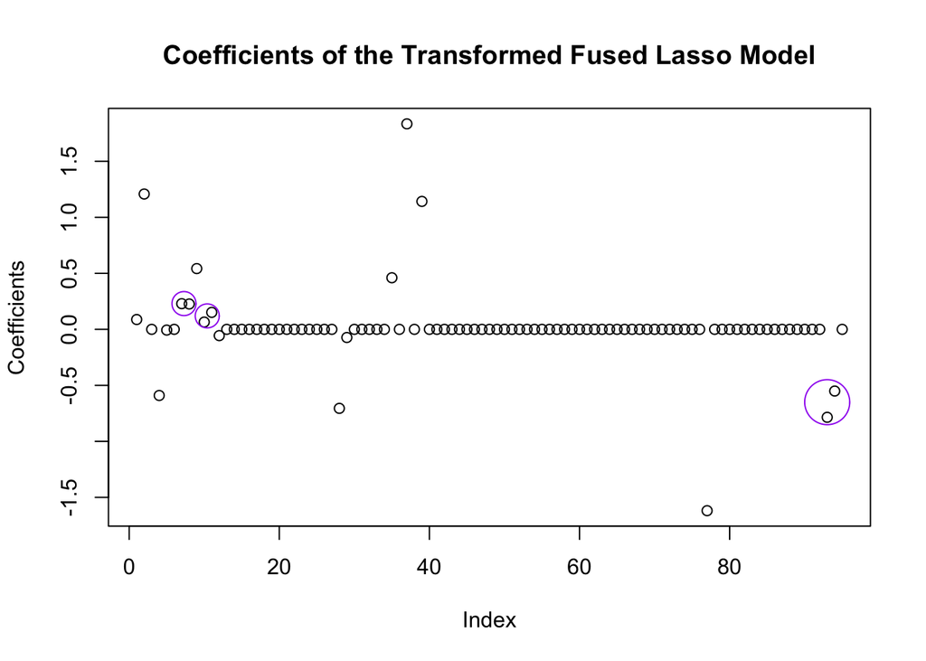

The regression coefficients are seen above. Here, there are more observations with nonzero coefficients. The consecutive nonzero coefficients can be considered to be close mostly as it can be seen inside the purple circles which is by the nature of the fused lasso. Here, the coefficients refer to if the change between the observation number and the next one play a significant role in explaining the class result. For example, if the first coefficient is nonzero (yes, in this case), it means that the change in the second observation compared to the first observation plays a significant role in the class labels.